# Motor de dos tiempos (parte 1)

### 1. Introducción

En los últimos años se ha restringido mucho el uso de estos motores fundamentalmente por problemas de contaminación y eficiencia. Actualmente son más raros de ver.

¿Dónde se usan ahora los motores de 2T? Por ejemplo en motosierras, desmalezadoras, cortadoras de pasto, etc. Los motores de 2 tiempos tienen una construcción muy sencilla. Abajo puedes ver un motor de dos tiempos justo cuando explota la mezcla aire-combustible.

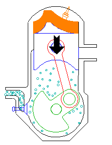

Source: https://animatedengines.com/twostroke.html

Cualquier explosión (fuego) requiere tres cosas:

- 1- Aire (oxígeno)
- 2- Combustible
- 3- Fuente de calor (chispa de la bujía)

### 2. Partes y funcionamiento de un motor de 2T

Repasa las partes principales con esta imagen:

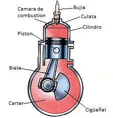

Fuente: motoresdedostiempos2t.blogspot.com.

**Funcionamiento básico**

En este [video](https://www.youtube.com/watch?v=g9kKzzkeJPQ) puedes ver que el motor tiene dos fases (tiempos):

- **1er tiempo (compresión + admisión):**
  - El pistón sube.
  - Se comprime la mezcla de aire-combustible.
  - Al mismo tiempo, entra mezcla al cárter.
- **2do tiempo (explosión + escape):**
  - Salta la chispa, explota la mezcla.
  - El pistón baja con fuerza (transmite energía).
  - Se expulsan los gases por el escape.
  - Entra nueva mezcla al cilindro.

#### Actividadades

**2)** Según la imagen de abajo, en donde se ve un motor de 2T real, une con flechas las letras con las partes del motor que se corresponden:

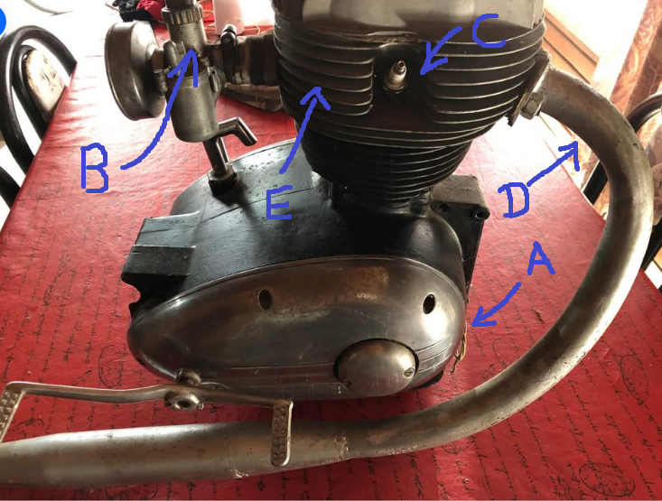

Fuente: facebook.com.

```
    A               Bujía

    B               Carter

    C               Cilindro

    D               Carburador

    E               Caño de escape
```

### 3. El Carburador

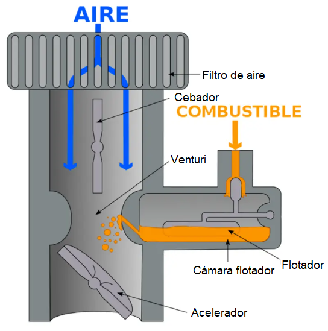

Diagrama de un carburador. Fuente: Wikipedia

El carburador mezcla el aire con el combustible en la proporción correcta para que el motor pueda funcionar. Es como “la cocina” del motor, porque prepara la mezcla antes de que entre al cilindro.

Las partes principales son:

- Filtro de aire: Evita que el polvo y diversas partículas entre al motor y lo rompa.
- Cebador: Cierra un poco el paso del aire para que la mezcla tenga más combustible. Sirve en el arranque cuando el motor está frío.
- Venturi: estrangula el pasaje de aire y esto permite que el aire aumente su velocidad y arrastre combustible
- Flotador y cámara del flotador: regula la cantidad de combustible
- Acelerador: Abre y cierra el pasaje de la mezcla aire-combustible. Cuando abre pasa más cantidad, el motor se llena y explota más rápido, aumenta la velocidad.

#### Actividad

**1)** Dibujar el esquema del carburador y poner con flechas los nombres de las partes y sus **funciones**.

**2)** Cuando el motor está andando pero no se apreta el acelerador para nada el carburador pone menos combustible en la mezcla y el motor gira a una velocidad estable. ¿Cómo se llama esta velocidad?